# Introduction

The ongoing pandemic of COVID-19 is still one of the most important priorities of governments and media of many countries all around the world. Due to the alarming levels of spread and severity, the World Health Organization (WHO) declared the outbreak a Public Health Emergency of International Concern (PHEIC) on 30 January 2020, and then a pandemic on 11 March 2020 [@world2020timeline]. As of 29 September 2021, more than 232.7 million cases of COVID-19 have been reported in over 192 countries and territories, resulting in more than 4.7 million deaths [@dong2020interactive]. In response to the pandemic, health authorities worldwide have taken many steps including vaccination development and deployment to minimize the spread of the virus. In addition, authorities worldwide have also taken many non-pharmaceutical interventions and preventive measures such as travel restrictions, lock-downs, workplace hazard controls, school/university closures, facility closures, reduction of mass gatherings to reduce the spread of the virus [@chang2020modelling].

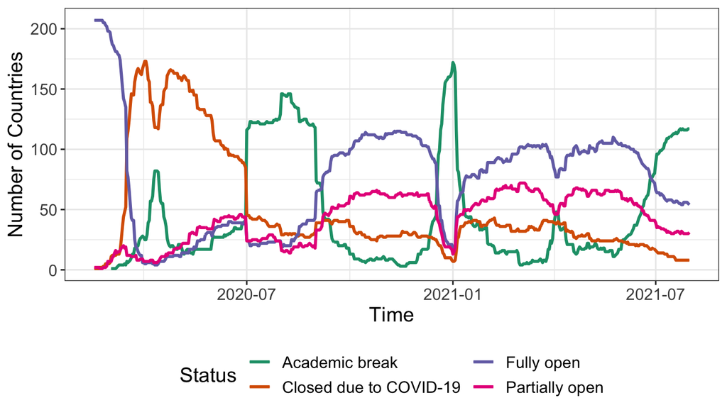

Global tracking of COVID-19 caused school closures and re-openings

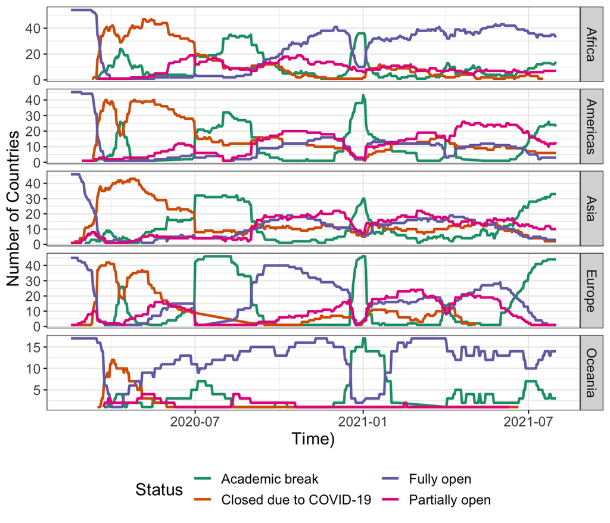

Region wise tracking of COVID-19 caused school closures and re-openings

The ongoing COVID-19 pandemic has brought the world to a standstill. Many sectors have been affected ever since the outbreak of COVID 19, worldwide. Among these many sectors education is one of the most affected sectors with a near-total closures of schools, colleges and universities, all around the world [@daniel2020education]. Figures shows the evolution of global school closures and reopening since mid February 2020. With the start of the pandemic a near total closure of schools were observed all around the world. Over time, Africa and Oceania demonstrated better recovery in comparison to other regions with their increasing number of fully open schools (Figures ).

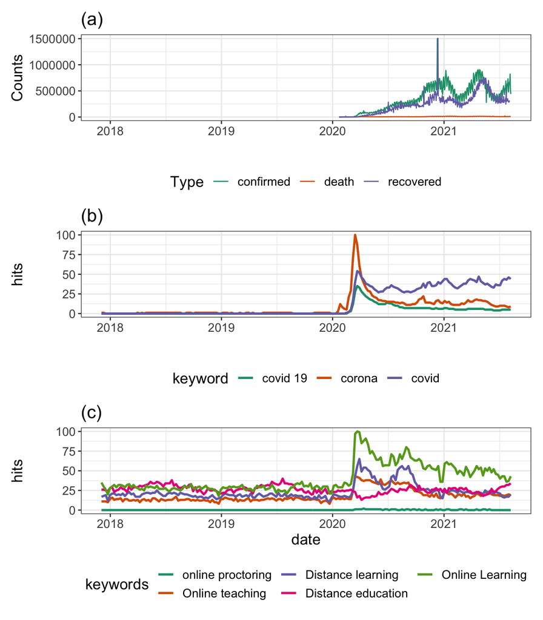

Visualization of data from Goolge search trends. (a) COVID-19 cases worldwide (b) Google search trends of COVID-19 related terms (c) Google search trends of distance education related terms.

Eventhough distance education has a long history that goes back to almost two centuries with significant modifications, alterations, and addition in the process of delivery and communication [@moore2011learning; @spector2014handbook], COVID 19 certainly made a new era of distance education while encouraging various stakeholders of education to take the concept of distance education seriously [@richmond2020critical]. Sudden unexpected movement from classrooms to home schooling at large scale made students, teachers and parents vulnerable, leading to millions of education related internet searches being performed during the period of COVID 19 pandemic (Figures ) [@carter2021teacher]. Surprisingly, the search spikes of distance education related searches (Figure (c)) coincide with increasing Covid-19 counts (Figure (a)) and related internet searches (Figure (b)), eventhough distance education has a long history in contrast to Covid-19 pandemic.

The speed of the physical classroom closures and the rapid move to online delivery of education allowed little time for planning or reflection on potential risks that could happen to its various stakeholders: teachers, students and parents. Teachers were not fully aware of their obligations and how to maintain connections with students to support thier learning. Lack of preparation, lack of tools and techniques for distance education, lack of awareness of the availability of the existing tools and techniques and their effectiveness, lack of interaction and communication with the students, lack of awareness of students’ ongoing problems were some of the major issues they encountered during COVID 19 pandemic. Students on the other hand who tend to have fewer educational opportunities beyond schools and universities severely affected from this sudden unexpected movement. Further, the impact was not limited to students’ learning but also to other aspects of their lives such as student debt, digital exclusion, lack of technology, lack of access to internet-enabled device or a stable internet connection, long-term educational disengagement, poor nutrition and food insecurity, increased psychological challenges, childcare problems, exploitation, school dropouts and lack of disability services, long-term educational disengagement, digital exclusion, poor technology management, increased psychosocial challenges, decreases in mathematical achievement, a lack of engagement, increased early marriages , psychosocial challenges [@drane2020impact; @daniel2020education; @unescoadverse2020; @richmond2020critical; @carter2021teacher]. This also put an extra burden on parents, specially with limited education and resources, as they were expected to facilitate the required learning environment at home. Working parents also found it difficult to work during school closure due to childcare obligations that result from unexpected school closures. Further, every single step including planning, developing new tools and techniques, conducting awareness programmes about distance education, shifting towards distance education, happened through online, due to the unexpected massive global shutdown. This situation left internet as the only medium to support all these educational processes.

In response to this gray situation and urgent requirement of massive transformation from physical classroom to virtual learning environment, UNESCO took immediate and timely action by publishing a long list of distance learning solutions that can be used to facilitate student distance learning during the period of school closure. There are many different distance learning solutions. Yet very little is known about the uptake of different solutions or about their effectiveness. The design of different types of distance learning solutions can depend on the learning objective, target audience, access, and type of content [@moore2011learning]. However, getting familiar with all these available distance solutions is not feasible or practical due to limited time availability and need of urgent responses. According to @carter2021teacher, for educators to continue to teach inclusively, they need support to connect with the students through a variety of strategies so that students feel not only connected to their teachers, but to the subject matter being taught.

Connectivity, flexibility and ability to promote varied interactions are some critical aspects, educators consider when selecting distance education solutions. Further, according to @ahn2006utilizing, the popularity of a product can also greatly influence consumer purchasing decisions as popularity can indicate the prominence of the product in the market, its usability and its impact. Further, according to @willis2020using, developers also tend to improve their products and services in response to increasing online search. Therefore, the internet represents a great opportunity to learn about public attention towards a product or service. It is also a way to narrow down the search space and thereby identify most suitable product and services that meets customer needs.

Google Trends is an open source web analytics tool that allows users to interact with Internet search data, which can provide deep insights into population behavior [@nuti2014use]. As there is still the main struggle as to what technologies should be used to facilitate student learning, in this study we test whether the Google Analytics search index series can be used as a proxy of the popularity and the public interest in different distance education solutions. In line with that, this paper makes three fundamental contributions to distance education by exploring three main questions: (1) What is the impact of COVID 19 pandemic on education? (2) What solutions are in place to meet the need of distance education in terms during COVID 19 pandemic? (3) Which distance learning solutions have a wide attention and public interest during the COVID-19 pandemic? We primarily analyze quantitative digital footprint data on the internet from December 2019 to August 2021. The resulted google trend footprint provides a fast first step to identify the most popular distance education tools available for different education purposes. It also allows the teachers to narrow down the search space and deepen their exploration on prominent distance education solutions to support their online teaching. Further, identifying most popular tools and techniques will allow everyone to focus on those methods and develop a sustainable learning environment by advancing the existing features.

Quality education is essential to sustainable development and it is a key United Nations (UN) sustainable development goal. Having the right tool is imperative to successful completion of a task at hand. The findings of this study provides an initial guidance to select a right tool. Therefore, the findings of this study directly contribute to UN’s sustainable development goals of quality education.

The remainder of this paper is organized as follows. Section 2 presents the related work to lay the foundation for the Google footprint analysis. Section 3 presents the methodology followed in the study. Section 4 includes Google footprint analysis. Section 5 concludes the article and presents future research directions.

## Background

Google Trends, is a freely accessible website sponsored by Google that analyzes spatio and temporal patterns of search queries in Google Search, across various regions, subject domains and languages [@carneiro2009google]. Therefore, Google trends provide a quantifiable and valuable measure of emerging public concerns and trending topics together with their geographic distribution [@alicino2015assessing; @cook2011assessing]. According to @jarynowski2020perception the public concerns on different matters can also take an epidemic nature starting with the phase of growing interest which is known as “early adoption”, to the phase of general interest which is known as “majority” to eventually lose popularity which is known as “lagers stage”. Figure also confirms this life cycle explanation.

The use of google trend search queries has become a popular data source in monitoring and modeling the dynamics of different domains such as disaster management [@kam2019monitoring], transportation [@willis2020using], business [@chumnumpan2019understanding] and health care [@nuti2014use; @alicino2015assessing; @arora2019google; @carneiro2009google; @cook2011assessing] as it provides data about social phenomena in a more timely manner than traditional data collection processes [@vaughan2014web]. According to the study conducted by @willis2020using on taxi preferences found that online queries can provide a proxy of quality of taxi services and thereby provide a means to investigate service quality and public concerns on the service provided. In November, 2008, Google launched an internet-based surveillance tool, Google Flu Trends (GFT), that uses aggregated Google search data to provide a near real-time support in predicting influenza outbreaks [@cook2011assessing]. Several recent studies have also been conducted to investigate the relation between Google search trend patterns and the COVID-19 related concerns [@husnayain2020applications; @effenberger2020association]. The study conducted by @husnayain2020applications focuses on search terms related to the coronavirus, handwashing, and face masks to monitor public restlessness toward COVID-19. However, there are only a limited number of research attempts related to education section using Google trend search query data [@vaughan2014web]. The study conducted by @vaughan2014web have used google trend search queries to predict academic fame by testing the correlation between search volume data and university ranking data. @kansal2021google have used a text mining approach to identify emerging patterns of words and phrases during COVID-19 pandemic, keeping education prospects as the focus. However, their study was limited to a small number of learning platforms. However, according to @moore2011learning the design of different types of learning environments can depend on the learning objective, target audience, access (physical, virtual and/or both), and type of content. Therefore, this study provides a detailed investigation on distance education solutions focusing on different distance learning needs. In contrast to the work in @kansal2021google, the work in our paper has a very specific focus: the distance learning solutions for various education purposes.

Eventhough google trend search quiries provide massive amount of data, more care should be given when utilizing it as a research tool. It may contain inaccuracies [@carneiro2009google]. According to @nuti2014use the data retrieval process should be transparent. This will increase the trustworthiness of both the results and the generalizability of the findings. Furthermore, researchers should clearly document the rationale and data retrieval process to ensure the reproducibility of results [@nuti2014use]. .

## Methodology

There are different types of interactions that facilitate learners to construct knowledge in distance education environments. These are learner–content interactions, learner–instructor interactions, learner–learner interactions and learner–interface interaction [@wallace2003online].

Google Trends determines categories based on search patterns. According to @vaughan2014web more relevant accurate data can be obtained by limiting the search in Google Trends to a specific category as it helps to reduce noise in the data. In this work our focus was given to education category. Google Trends does not provide the absolute search volume of a given search term. Instead it provides a relative search volume of a particular term adjusted according to the total searches of the geography and time range it represents. The resulted series scale from 0 to 100, where each data point in the series represents the search interest relative to the highest point on the series for the selected region and time. [@alicino2015assessing; @vaughan2014web]. A value of 100 represents the peak popularity of the term.

The term distance education is known by a variety of names. The terms such as distance learning, e-Learning, online learning environments, home study, independent study, external study, correspondence education, off campus study, open learning and open education are used commonly and interchangeably [@moore2011learning]. It often describes the effort of providing access to learning for those who are geographically distant. The definition also stated that distance education uses emerging media and associated experiences to produce distributed learning opportunities. Few common features found in all these terms is they all involve some form of instruction occurs between two parties; learners and teachers, different times, places and/or varying forms of instructional materials [@moore2011learning]. It is important to decide what term to search for in Google Trends as different terms have different search volumes. In the past literature several strategies have been used to select suitable search terms for a given study. Some studies have selected search terms based on intuition and some through brainstorming processes [@vaughan2014web]. In this study our choice of search term took into account the list of distance learning solutions published by UNESCO [@unesco2020DLsolutions]. Eventhough, the solutions they had recommended do not carry their explicit endorsement, they tend to have a wide reach, a strong user-base and evidence of impact [@unesco2020DLsolutions]. Different solutions are categorized based on distance learning needs. For each keyword, the worldwide search queries were performed with a keyword being used as the “search term”. That allowed us to search the exact string of text typed by the user. However, according to @vaughan2014web, short forms or acronyms had higher search volumes than the corresponding complete names, in general. However we did not use the acronym in this study, as our focus is on specific tools and techniques available in the market to fulfill distance education needs and acronyms could be confused with another entity.

Google Trends allows to search for up to five queries each time [@vaughan2014web]. We did our analysis under 11 sub segmentations namely, digital learning management systems, systems built for use on basic mobile phones, systems with strong offline functionality, Massive Open Online Course (MOOC) Platforms, self-directed learning content, mobile reading applications, Collaboration platforms that support live-video communication, tools for teachers to create of digital learning content, external repositories of distance learning solutions, tools for online proctoring and Resources to provide psychosocial support. The segmentation was mainly motivated by the list of distance learning solutions published by UNESCO in response to Covid 19 pandemic.

In google trends, it is possible to search for only up to five queries at a time. Therefore, under each segmentation we entered up to five distance learning tools at a time and recorded their relative ranking scores. An iterative pairwise comparison was first used to identify the series that has highest search volume during the study period. Through this iterative process of relative comparison, we were able to identify the tool with the highest relative ranking score. Then the relative ranking scores for all the other tools in the given segmentation was obtained relative to the previously detected series with the highest ranking scores [@vaughan2014web].

## Results

Search volume index graphs for Covid 19 related terms worldwide (Figures (b)) shows that the highest peak coincided with the start of the pandemic. Surprisingly, the search volume index graph for distanced education related terms (Figures (c)) also shows a similar spike at the start of the pandemic. According to @moore2011learning, “distance education” is the most renowned descriptor used when referencing distance learning. However, both @benson2002usability and @conrad2002deep introduced “online learning” as the most “recent version”, “never version” and “improved version” of distance learning. The google search trend pattern corresponds to the term “online learning” (Figures (c)) confirms the above claim as it is the most searched distance education related term throughout Covid-19 pandemic. Despite quantitative differences in terms of relative search volume, the series generated by the two terms “Distance learning” and “online teaching” demonstrate a similar trend during the study period. Covid-19 related web searches declined in the months after the WHO announcement of the Covid-19 pandemic, despite the increase in Covid-19 cases. A similar decline could be detected in distance education related terms. further, a second was observed only in education related terms after the WHO announcement of the Covid-19 pandemic. This could be due to the near total closures of schools happened with the declaration of Covid-19 as a pandemic.

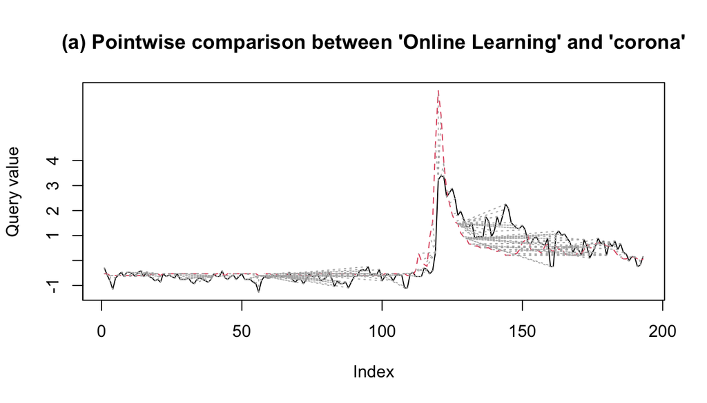

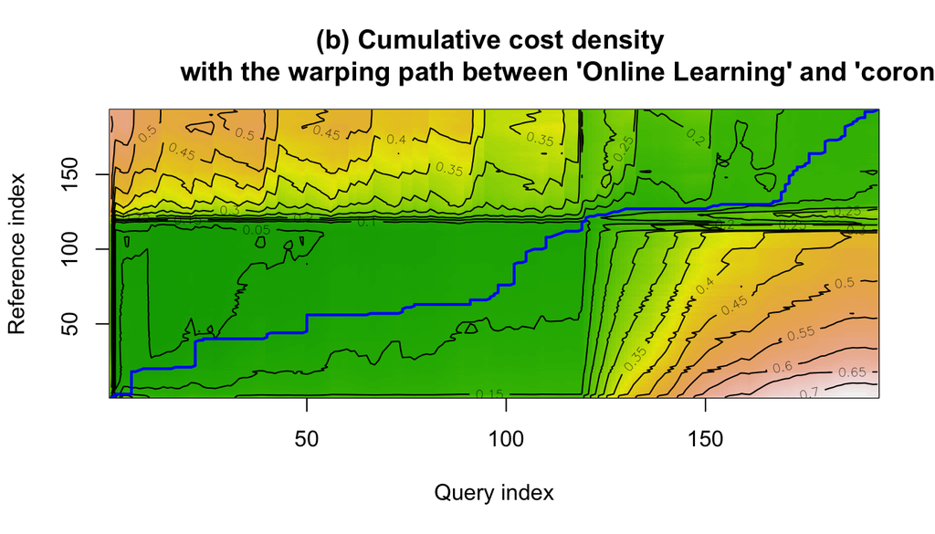

Visualization of Dynamic Time Warping Alignments between ‘online learning’ and ‘corona’

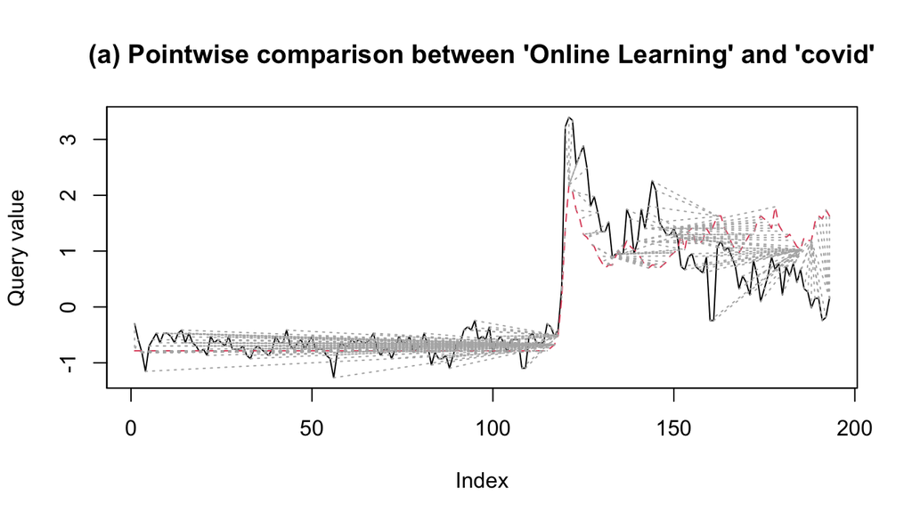

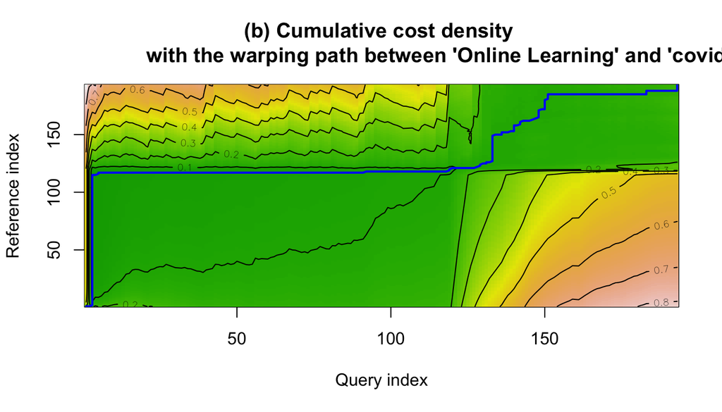

Visualization of Dynamic Time Warping Alignments ‘online learning’ and ‘covid’

The pairwise comparison performed using Dynamic Time Warping algorithm. Under this approach the two time series are stretched or compressed locally in order to make one resemble the other as much as possible. The distance between the two series is then computed by summing the distances of individual aligned elements [@giorgino2009computing]. Two pairwise comparisons, “corona” with “online learning” and “covid” with “online learning” were conducted to see the impact from covid 19 on distance education. Both pairwise comparison show a significant areas of overlap and a similar dynamic pattern (Figures (a) and (a)). The normalized distance between the two series in the two comparisons are 0.1326197 and 0.1828299, respectively. This also provides further confirmation for the similarity of the google trend search profiles.

The entirety of the blue warping path flows through green pastures further confirms the similarity between the search pattern related to covid 19 and distance education (Figures (b) and (b)). The orange volcanic topography that highlights regions of nonalignment of series in question if mapped through this region demonstrate a significant difference in online search behaviours before and after covid 19 pandemic (Figures (b) and (b)).

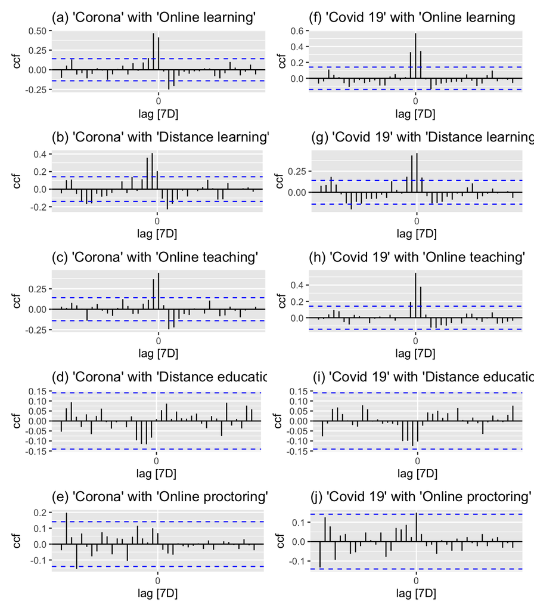

Cross-correlation analysis between distance learning related online search terms and covid 19 relate online search terms during Covid-19 pandemic

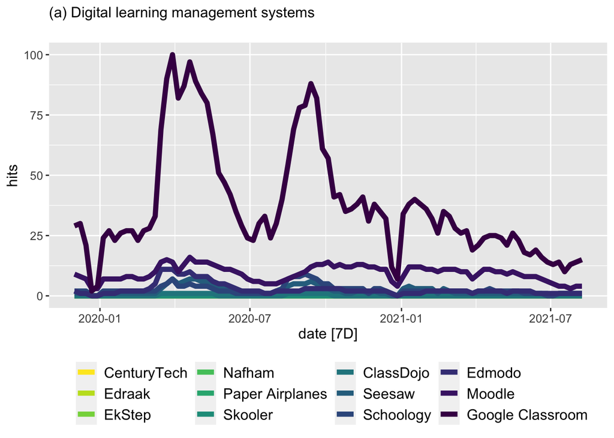

## exams

Strategies to postpone, skip or adminsiter examinations at a distance raise serious concerns about fairness, especialy when access to learning becomes variable. Disruptions to assessments results in stress for students and their families and can trigger disengagement. [@unesco2020covid; @unescoadverse2020]

## Discussion and Conclusion

The lack of consistency in terminology inevitably affects not only the researchers who would like to build upon the findings, but also impacts designers who are creating similar types of environments. The findings show great differences in the meaning of foundational terms that are used in the field, but also provide implications internationally for the referencing, sharing, and the collaboration of results detailed in varying research studies (Moore, Dickson-Deane & Galyen 2011).